# Optimal Treatment Analysis

## Outcome Variable

**Outcome Variable:** ever_stunted

## Predictor Variables

**Intervention Variable:** perdiar6

**Adjustment Set:**

- arm
- sex
- W_mage
- meducyrs
- W_mhtcm
- W_mwtkg
- W_mbmi
- W_birthwt
- W_birthlen
- W_nrooms
- month
- brthmon
- impfloor
- impsan
- safeh20
- delta_W_mage
- delta_meducyrs
- delta_W_mhtcm
- delta_W_mwtkg
- delta_W_mbmi
- delta_W_birthwt
- delta_W_birthlen
- delta_W_nrooms
- delta_month
- delta_brthmon
- delta_impfloor
- delta_impsan
- delta_safeh20

## Stratifying Variables

The analysis was stratified on these variable(s):

- agecat
- studyid
- country

## Data Summary

| agecat | studyid | country | perdiar6 | ever_stunted | n_cell | n |
| --- | --- | --- | --- | --- | --- | --- |
| 0-24 months (no birth st.) | ki0047075b-MAL-ED | BANGLADESH | (0%, 5%] | 0 | 41 | 217 |
| 0-24 months (no birth st.) | ki0047075b-MAL-ED | BANGLADESH | (0%, 5%] | 1 | 44 | 217 |
| 0-24 months (no birth st.) | ki0047075b-MAL-ED | BANGLADESH | 0% | 0 | 36 | 217 |
| 0-24 months (no birth st.) | ki0047075b-MAL-ED | BANGLADESH | 0% | 1 | 36 | 217 |
| 0-24 months (no birth st.) | ki0047075b-MAL-ED | BANGLADESH | >5% | 0 | 27 | 217 |
| 0-24 months (no birth st.) | ki0047075b-MAL-ED | BANGLADESH | >5% | 1 | 33 | 217 |
| 0-24 months (no birth st.) | ki0047075b-MAL-ED | BRAZIL | (0%, 5%] | 0 | 12 | 208 |
| 0-24 months (no birth st.) | ki0047075b-MAL-ED | BRAZIL | (0%, 5%] | 1 | 2 | 208 |
| 0-24 months (no birth st.) | ki0047075b-MAL-ED | BRAZIL | 0% | 0 | 165 | 208 |
| 0-24 months (no birth st.) | ki0047075b-MAL-ED | BRAZIL | 0% | 1 | 27 | 208 |
| 0-24 months (no birth st.) | ki0047075b-MAL-ED | BRAZIL | >5% | 0 | 2 | 208 |
| 0-24 months (no birth st.) | ki0047075b-MAL-ED | BRAZIL | >5% | 1 | 0 | 208 |
| 0-24 months (no birth st.) | ki0047075b-MAL-ED | INDIA | (0%, 5%] | 0 | 54 | 209 |
| 0-24 months (no birth st.) | ki0047075b-MAL-ED | INDIA | (0%, 5%] | 1 | 52 | 209 |
| 0-24 months (no birth st.) | ki0047075b-MAL-ED | INDIA | 0% | 0 | 24 | 209 |
| 0-24 months (no birth st.) | ki0047075b-MAL-ED | INDIA | 0% | 1 | 25 | 209 |
| 0-24 months (no birth st.) | ki0047075b-MAL-ED | INDIA | >5% | 0 | 23 | 209 |
| 0-24 months (no birth st.) | ki0047075b-MAL-ED | INDIA | >5% | 1 | 31 | 209 |
| 0-24 months (no birth st.) | ki0047075b-MAL-ED | NEPAL | (0%, 5%] | 0 | 54 | 212 |
| 0-24 months (no birth st.) | ki0047075b-MAL-ED | NEPAL | (0%, 5%] | 1 | 14 | 212 |
| 0-24 months (no birth st.) | ki0047075b-MAL-ED | NEPAL | 0% | 0 | 54 | 212 |
| 0-24 months (no birth st.) | ki0047075b-MAL-ED | NEPAL | 0% | 1 | 20 | 212 |
| 0-24 months (no birth st.) | ki0047075b-MAL-ED | NEPAL | >5% | 0 | 49 | 212 |
| 0-24 months (no birth st.) | ki0047075b-MAL-ED | NEPAL | >5% | 1 | 21 | 212 |
| 0-24 months (no birth st.) | ki0047075b-MAL-ED | PERU | (0%, 5%] | 0 | 29 | 266 |
| 0-24 months (no birth st.) | ki0047075b-MAL-ED | PERU | (0%, 5%] | 1 | 51 | 266 |
| 0-24 months (no birth st.) | ki0047075b-MAL-ED | PERU | 0% | 0 | 37 | 266 |
| 0-24 months (no birth st.) | ki0047075b-MAL-ED | PERU | 0% | 1 | 40 | 266 |
| 0-24 months (no birth st.) | ki0047075b-MAL-ED | PERU | >5% | 0 | 49 | 266 |
| 0-24 months (no birth st.) | ki0047075b-MAL-ED | PERU | >5% | 1 | 60 | 266 |

[output cut: 258 more lines]

The following strata were considered:

- agecat: 0-24 months (no birth st.), studyid: ki0047075b-MAL-ED, country: BANGLADESH
- agecat: 0-24 months (no birth st.), studyid: ki0047075b-MAL-ED, country: BRAZIL
- agecat: 0-24 months (no birth st.), studyid: ki0047075b-MAL-ED, country: INDIA
- agecat: 0-24 months (no birth st.), studyid: ki0047075b-MAL-ED, country: NEPAL
- agecat: 0-24 months (no birth st.), studyid: ki0047075b-MAL-ED, country: PERU
- agecat: 0-24 months (no birth st.), studyid: ki0047075b-MAL-ED, country: SOUTH AFRICA
- agecat: 0-24 months (no birth st.), studyid: ki0047075b-MAL-ED, country: TANZANIA, UNITED REPUBLIC OF
- agecat: 0-24 months (no birth st.), studyid: ki1000109-ResPak, country: PAKISTAN
- agecat: 0-24 months (no birth st.), studyid: ki1017093-NIH-Birth, country: BANGLADESH
- agecat: 0-24 months (no birth st.), studyid: ki1017093b-PROVIDE, country: BANGLADESH
- agecat: 0-24 months (no birth st.), studyid: ki1017093c-NIH-Crypto, country: BANGLADESH
- agecat: 0-24 months (no birth st.), studyid: ki1114097-CMIN, country: BANGLADESH
- agecat: 0-24 months (no birth st.), studyid: ki1114097-CMIN, country: BRAZIL
- agecat: 0-24 months (no birth st.), studyid: ki1114097-CMIN, country: GUINEA-BISSAU
- agecat: 0-24 months (no birth st.), studyid: ki1114097-CMIN, country: PERU
- agecat: 0-24 months (no birth st.), studyid: ki1114097-CONTENT, country: PERU
- agecat: 0-6 months (no birth st.), studyid: ki0047075b-MAL-ED, country: BANGLADESH
- agecat: 0-6 months (no birth st.), studyid: ki0047075b-MAL-ED, country: BRAZIL
- agecat: 0-6 months (no birth st.), studyid: ki0047075b-MAL-ED, country: INDIA
- agecat: 0-6 months (no birth st.), studyid: ki0047075b-MAL-ED, country: NEPAL
- agecat: 0-6 months (no birth st.), studyid: ki0047075b-MAL-ED, country: PERU
- agecat: 0-6 months (no birth st.), studyid: ki0047075b-MAL-ED, country: SOUTH AFRICA
- agecat: 0-6 months (no birth st.), studyid: ki0047075b-MAL-ED, country: TANZANIA, UNITED REPUBLIC OF
- agecat: 0-6 months (no birth st.), studyid: ki1000109-ResPak, country: PAKISTAN
- agecat: 0-6 months (no birth st.), studyid: ki1017093-NIH-Birth, country: BANGLADESH
- agecat: 0-6 months (no birth st.), studyid: ki1017093b-PROVIDE, country: BANGLADESH
- agecat: 0-6 months (no birth st.), studyid: ki1017093c-NIH-Crypto, country: BANGLADESH
- agecat: 0-6 months (no birth st.), studyid: ki1114097-CMIN, country: BANGLADESH
- agecat: 0-6 months (no birth st.), studyid: ki1114097-CMIN, country: BRAZIL
- agecat: 0-6 months (no birth st.), studyid: ki1114097-CMIN, country: GUINEA-BISSAU
- agecat: 0-6 months (no birth st.), studyid: ki1114097-CMIN, country: PERU
- agecat: 0-6 months (no birth st.), studyid: ki1114097-CONTENT, country: PERU
- agecat: 6-24 months, studyid: ki0047075b-MAL-ED, country: BANGLADESH
- agecat: 6-24 months, studyid: ki0047075b-MAL-ED, country: BRAZIL
- agecat: 6-24 months, studyid: ki0047075b-MAL-ED, country: INDIA
- agecat: 6-24 months, studyid: ki0047075b-MAL-ED, country: NEPAL
- agecat: 6-24 months, studyid: ki0047075b-MAL-ED, country: PERU
- agecat: 6-24 months, studyid: ki0047075b-MAL-ED, country: SOUTH AFRICA
- agecat: 6-24 months, studyid: ki0047075b-MAL-ED, country: TANZANIA, UNITED REPUBLIC OF
- agecat: 6-24 months, studyid: ki1000109-ResPak, country: PAKISTAN
- agecat: 6-24 months, studyid: ki1017093-NIH-Birth, country: BANGLADESH
- agecat: 6-24 months, studyid: ki1017093b-PROVIDE, country: BANGLADESH
- agecat: 6-24 months, studyid: ki1017093c-NIH-Crypto, country: BANGLADESH
- agecat: 6-24 months, studyid: ki1114097-CMIN, country: BANGLADESH
- agecat: 6-24 months, studyid: ki1114097-CMIN, country: BRAZIL
- agecat: 6-24 months, studyid: ki1114097-CMIN, country: GUINEA-BISSAU
- agecat: 6-24 months, studyid: ki1114097-CMIN, country: PERU
- agecat: 6-24 months, studyid: ki1114097-CONTENT, country: PERU

### Dropped Strata

Some strata were dropped due to rare outcomes:

- agecat: 0-24 months (no birth st.), studyid: ki0047075b-MAL-ED, country: BRAZIL
- agecat: 0-24 months (no birth st.), studyid: ki0047075b-MAL-ED, country: SOUTH AFRICA
- agecat: 0-6 months (no birth st.), studyid: ki0047075b-MAL-ED, country: BRAZIL
- agecat: 0-6 months (no birth st.), studyid: ki0047075b-MAL-ED, country: NEPAL
- agecat: 0-6 months (no birth st.), studyid: ki0047075b-MAL-ED, country: SOUTH AFRICA
- agecat: 0-6 months (no birth st.), studyid: ki1114097-CMIN, country: BRAZIL
- agecat: 0-6 months (no birth st.), studyid: ki1114097-CMIN, country: GUINEA-BISSAU
- agecat: 0-6 months (no birth st.), studyid: ki1114097-CONTENT, country: PERU
- agecat: 6-24 months, studyid: ki0047075b-MAL-ED, country: BRAZIL
- agecat: 6-24 months, studyid: ki0047075b-MAL-ED, country: SOUTH AFRICA
- agecat: 6-24 months, studyid: ki1000109-ResPak, country: PAKISTAN
- agecat: 6-24 months, studyid: ki1114097-CONTENT, country: PERU

## Methods Detail

We’re interested in the causal parameters $E[Y_a]$ for all values of $a \in \mathcal{A}$. These parameters represent the mean outcome if, possibly contrary to fact, we intervened to set all units to have $A=a$. Under the randomization and positivity assumptions, these are identified by the statistical parameters $\psi_a=E_W[E_{Y|A,W}(Y|A=a,W)]$. In addition, we’re interested in the mean of $Y$, $E[Y]$ under no intervention (the observed mean). We will estimate these parameters by using SuperLearner to fit the relevant likelihood factors – $E_{Y|A,W}(Y|A=a,W)$ and $p(A=a|W)$, and then updating our likelihood fit using a joint TMLE.

For unadjusted analyses ($W=\{\}$), initial likelihoods were estimated using Lrnr_glm to estimate the simple $E(Y|A)$ and Lrnr_mean to estimate $p(A)$. For adjusted analyses, a small library containing Lrnr_glmnet, Lrnr_xgboost, and Lrnr_mean was used.

# Results Detail

## Results Plots

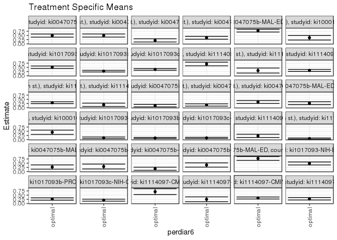

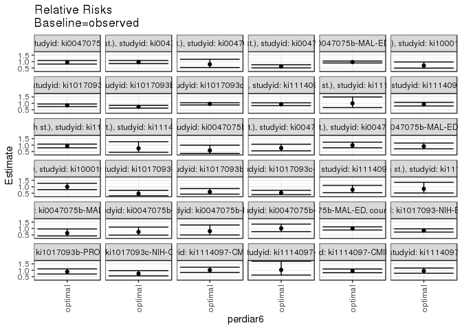

## Results Table

### Parameter: TSM

| agecat | studyid | country | intervention_level | baseline_level | estimate | ci_lower | ci_upper |
| --- | --- | --- | --- | --- | --- | --- | --- |
| 0-24 months (no birth st.) | ki0047075b-MAL-ED | BANGLADESH | optimal | NA | 0.4915628 | 0.3984338 | 0.5846918 |
| 0-24 months (no birth st.) | ki0047075b-MAL-ED | INDIA | optimal | NA | 0.4955582 | 0.4030776 | 0.5880388 |
| 0-24 months (no birth st.) | ki0047075b-MAL-ED | NEPAL | optimal | NA | 0.2068408 | 0.1108473 | 0.3028342 |
| 0-24 months (no birth st.) | ki0047075b-MAL-ED | PERU | optimal | NA | 0.3620907 | 0.2766478 | 0.4475336 |
| 0-24 months (no birth st.) | ki0047075b-MAL-ED | TANZANIA, UNITED REPUBLIC OF | optimal | NA | 0.7857856 | 0.7028611 | 0.8687100 |
| 0-24 months (no birth st.) | ki1000109-ResPak | PAKISTAN | optimal | NA | 0.3637268 | 0.2267008 | 0.5007528 |
| 0-24 months (no birth st.) | ki1017093-NIH-Birth | BANGLADESH | optimal | NA | 0.5088902 | 0.4361848 | 0.5815956 |
| 0-24 months (no birth st.) | ki1017093b-PROVIDE | BANGLADESH | optimal | NA | 0.2747970 | 0.2251899 | 0.3244042 |
| 0-24 months (no birth st.) | ki1017093c-NIH-Crypto | BANGLADESH | optimal | NA | 0.3775162 | 0.3279918 | 0.4270407 |
| 0-24 months (no birth st.) | ki1114097-CMIN | BANGLADESH | optimal | NA | 0.7024143 | 0.5937907 | 0.8110379 |
| 0-24 months (no birth st.) | ki1114097-CMIN | BRAZIL | optimal | NA | 0.3119422 | 0.1638134 | 0.4600709 |
| 0-24 months (no birth st.) | ki1114097-CMIN | GUINEA-BISSAU | optimal | NA | 0.3204431 | 0.2621013 | 0.3787849 |
| 0-24 months (no birth st.) | ki1114097-CMIN | PERU | optimal | NA | 0.2974254 | 0.2404020 | 0.3544489 |
| 0-24 months (no birth st.) | ki1114097-CONTENT | PERU | optimal | NA | 0.1714008 | 0.0700587 | 0.2727429 |
| 0-6 months (no birth st.) | ki0047075b-MAL-ED | BANGLADESH | optimal | NA | 0.1241234 | 0.0498550 | 0.1983918 |
| 0-6 months (no birth st.) | ki0047075b-MAL-ED | INDIA | optimal | NA | 0.1619978 | 0.0921703 | 0.2318254 |
| 0-6 months (no birth st.) | ki0047075b-MAL-ED | PERU | optimal | NA | 0.3404463 | 0.2547418 | 0.4261508 |
| 0-6 months (no birth st.) | ki0047075b-MAL-ED | TANZANIA, UNITED REPUBLIC OF | optimal | NA | 0.2691875 | 0.1825605 | 0.3558145 |
| 0-6 months (no birth st.) | ki1000109-ResPak | PAKISTAN | optimal | NA | 0.4372398 | 0.3100366 | 0.5644429 |
| 0-6 months (no birth st.) | ki1017093-NIH-Birth | BANGLADESH | optimal | NA | 0.1072867 | 0.0566496 | 0.1579239 |
| 0-6 months (no birth st.) | ki1017093b-PROVIDE | BANGLADESH | optimal | NA | 0.0967512 | 0.0588103 | 0.1346922 |
| 0-6 months (no birth st.) | ki1017093c-NIH-Crypto | BANGLADESH | optimal | NA | 0.1027736 | 0.0654022 | 0.1401451 |
| 0-6 months (no birth st.) | ki1114097-CMIN | BANGLADESH | optimal | NA | 0.2217402 | 0.1227087 | 0.3207716 |
| 0-6 months (no birth st.) | ki1114097-CMIN | PERU | optimal | NA | 0.0623720 | 0.0282914 | 0.0964526 |
| 6-24 months | ki0047075b-MAL-ED | BANGLADESH | optimal | NA | 0.2703680 | 0.1436872 | 0.3970489 |
| 6-24 months | ki0047075b-MAL-ED | INDIA | optimal | NA | 0.3002634 | 0.1561920 | 0.4443347 |
| 6-24 months | ki0047075b-MAL-ED | NEPAL | optimal | NA | 0.1682303 | 0.0753621 | 0.2610985 |
| 6-24 months | ki0047075b-MAL-ED | PERU | optimal | NA | 0.3921346 | 0.2644354 | 0.5198338 |
| 6-24 months | ki0047075b-MAL-ED | TANZANIA, UNITED REPUBLIC OF | optimal | NA | 0.7803604 | 0.6685237 | 0.8921970 |
| 6-24 months | ki1017093-NIH-Birth | BANGLADESH | optimal | NA | 0.4827168 | 0.3937332 | 0.5717003 |
| 6-24 months | ki1017093b-PROVIDE | BANGLADESH | optimal | NA | 0.2664809 | 0.1956716 | 0.3372901 |
| 6-24 months | ki1017093c-NIH-Crypto | BANGLADESH | optimal | NA | 0.1968206 | 0.1369814 | 0.2566598 |
| 6-24 months | ki1114097-CMIN | BANGLADESH | optimal | NA | 0.7048949 | 0.5315974 | 0.8781923 |
| 6-24 months | ki1114097-CMIN | BRAZIL | optimal | NA | 0.2503990 | 0.1048197 | 0.3959783 |
| 6-24 months | ki1114097-CMIN | GUINEA-BISSAU | optimal | NA | 0.3277567 | 0.2688299 | 0.3866835 |
| 6-24 months | ki1114097-CMIN | PERU | optimal | NA | 0.2787551 | 0.2088018 | 0.3487083 |

### Parameter: E(Y)

| agecat | studyid | country | intervention_level | baseline_level | estimate | ci_lower | ci_upper |
| --- | --- | --- | --- | --- | --- | --- | --- |
| 0-24 months (no birth st.) | ki0047075b-MAL-ED | BANGLADESH | observed | NA | 0.5220850 | 0.4554630 | 0.5887069 |
| 0-24 months (no birth st.) | ki0047075b-MAL-ED | INDIA | observed | NA | 0.5141943 | 0.4462829 | 0.5821057 |
| 0-24 months (no birth st.) | ki0047075b-MAL-ED | NEPAL | observed | NA | 0.2596657 | 0.2005229 | 0.3188085 |
| 0-24 months (no birth st.) | ki0047075b-MAL-ED | PERU | observed | NA | 0.5807780 | 0.5211320 | 0.6404239 |
| 0-24 months (no birth st.) | ki0047075b-MAL-ED | TANZANIA, UNITED REPUBLIC OF | observed | NA | 0.8119509 | 0.7601690 | 0.8637327 |
| 0-24 months (no birth st.) | ki1000109-ResPak | PAKISTAN | observed | NA | 0.5228584 | 0.4536327 | 0.5920841 |
| 0-24 months (no birth st.) | ki1017093-NIH-Birth | BANGLADESH | observed | NA | 0.6034937 | 0.5617417 | 0.6452457 |
| 0-24 months (no birth st.) | ki1017093b-PROVIDE | BANGLADESH | observed | NA | 0.3768830 | 0.3391611 | 0.4146048 |
| 0-24 months (no birth st.) | ki1017093c-NIH-Crypto | BANGLADESH | observed | NA | 0.3941423 | 0.3566428 | 0.4316417 |
| 0-24 months (no birth st.) | ki1114097-CMIN | BANGLADESH | observed | NA | 0.7550499 | 0.6899059 | 0.8201939 |
| 0-24 months (no birth st.) | ki1114097-CMIN | BRAZIL | observed | NA | 0.3114544 | 0.2264089 | 0.3965000 |
| 0-24 months (no birth st.) | ki1114097-CMIN | GUINEA-BISSAU | observed | NA | 0.3444284 | 0.3112748 | 0.3775821 |
| 0-24 months (no birth st.) | ki1114097-CMIN | PERU | observed | NA | 0.3227405 | 0.2873609 | 0.3581202 |
| 0-24 months (no birth st.) | ki1114097-CONTENT | PERU | observed | NA | 0.2298427 | 0.1710691 | 0.2886162 |
| 0-6 months (no birth st.) | ki0047075b-MAL-ED | BANGLADESH | observed | NA | 0.2120060 | 0.1575007 | 0.2665113 |
| 0-6 months (no birth st.) | ki0047075b-MAL-ED | INDIA | observed | NA | 0.2105005 | 0.1550968 | 0.2659041 |
| 0-6 months (no birth st.) | ki0047075b-MAL-ED | PERU | observed | NA | 0.3459326 | 0.2886646 | 0.4032006 |
| 0-6 months (no birth st.) | ki0047075b-MAL-ED | TANZANIA, UNITED REPUBLIC OF | observed | NA | 0.2974616 | 0.2368169 | 0.3581062 |
| 0-6 months (no birth st.) | ki1000109-ResPak | PAKISTAN | observed | NA | 0.4376949 | 0.3689378 | 0.5064520 |
| 0-6 months (no birth st.) | ki1017093-NIH-Birth | BANGLADESH | observed | NA | 0.2289829 | 0.1930990 | 0.2648667 |
| 0-6 months (no birth st.) | ki1017093b-PROVIDE | BANGLADESH | observed | NA | 0.1595140 | 0.1310050 | 0.1880229 |
| 0-6 months (no birth st.) | ki1017093c-NIH-Crypto | BANGLADESH | observed | NA | 0.1929692 | 0.1628634 | 0.2230750 |
| 0-6 months (no birth st.) | ki1114097-CMIN | BANGLADESH | observed | NA | 0.2853132 | 0.2167973 | 0.3538292 |
| 0-6 months (no birth st.) | ki1114097-CMIN | PERU | observed | NA | 0.0744164 | 0.0543419 | 0.0944910 |
| 6-24 months | ki0047075b-MAL-ED | BANGLADESH | observed | NA | 0.4214604 | 0.3444670 | 0.4984538 |
| 6-24 months | ki0047075b-MAL-ED | INDIA | observed | NA | 0.4067668 | 0.3290049 | 0.4845287 |
| 6-24 months | ki0047075b-MAL-ED | NEPAL | observed | NA | 0.2107433 | 0.1534023 | 0.2680842 |
| 6-24 months | ki0047075b-MAL-ED | PERU | observed | NA | 0.3874981 | 0.3087068 | 0.4662894 |
| 6-24 months | ki0047075b-MAL-ED | TANZANIA, UNITED REPUBLIC OF | observed | NA | 0.7797377 | 0.7120027 | 0.8474727 |
| 6-24 months | ki1017093-NIH-Birth | BANGLADESH | observed | NA | 0.5741088 | 0.5218522 | 0.6263654 |
| 6-24 months | ki1017093b-PROVIDE | BANGLADESH | observed | NA | 0.3001701 | 0.2581183 | 0.3422219 |
| 6-24 months | ki1017093c-NIH-Crypto | BANGLADESH | observed | NA | 0.2659415 | 0.2275502 | 0.3043327 |
| 6-24 months | ki1114097-CMIN | BANGLADESH | observed | NA | 0.6958489 | 0.6112008 | 0.7804971 |
| 6-24 months | ki1114097-CMIN | BRAZIL | observed | NA | 0.2431149 | 0.1605910 | 0.3256388 |
| 6-24 months | ki1114097-CMIN | GUINEA-BISSAU | observed | NA | 0.3467415 | 0.3131033 | 0.3803798 |
| 6-24 months | ki1114097-CMIN | PERU | observed | NA | 0.2939755 | 0.2570246 | 0.3309264 |

### Parameter: RR

| agecat | studyid | country | intervention_level | baseline_level | estimate | ci_lower | ci_upper |
| --- | --- | --- | --- | --- | --- | --- | --- |
| 0-24 months (no birth st.) | ki0047075b-MAL-ED | BANGLADESH | optimal | observed | 0.9415379 | 0.8113067 | 1.0926739 |
| 0-24 months (no birth st.) | ki0047075b-MAL-ED | INDIA | optimal | observed | 0.9637567 | 0.8499305 | 1.0928270 |
| 0-24 months (no birth st.) | ki0047075b-MAL-ED | NEPAL | optimal | observed | 0.7965656 | 0.5361846 | 1.1833924 |
| 0-24 months (no birth st.) | ki0047075b-MAL-ED | PERU | optimal | observed | 0.6234580 | 0.5157765 | 0.7536207 |
| 0-24 months (no birth st.) | ki0047075b-MAL-ED | TANZANIA, UNITED REPUBLIC OF | optimal | observed | 0.9677747 | 0.8959085 | 1.0454058 |
| 0-24 months (no birth st.) | ki1000109-ResPak | PAKISTAN | optimal | observed | 0.6956507 | 0.4971385 | 0.9734307 |
| 0-24 months (no birth st.) | ki1017093-NIH-Birth | BANGLADESH | optimal | observed | 0.8432403 | 0.7503348 | 0.9476493 |
| 0-24 months (no birth st.) | ki1017093b-PROVIDE | BANGLADESH | optimal | observed | 0.7291309 | 0.6298632 | 0.8440435 |
| 0-24 months (no birth st.) | ki1017093c-NIH-Crypto | BANGLADESH | optimal | observed | 0.9578172 | 0.8757195 | 1.0476115 |
| 0-24 months (no birth st.) | ki1114097-CMIN | BANGLADESH | optimal | observed | 0.9302886 | 0.8287272 | 1.0442965 |
| 0-24 months (no birth st.) | ki1114097-CMIN | BRAZIL | optimal | observed | 1.0015661 | 0.6708103 | 1.4954072 |
| 0-24 months (no birth st.) | ki1114097-CMIN | GUINEA-BISSAU | optimal | observed | 0.9303619 | 0.7988928 | 1.0834662 |
| 0-24 months (no birth st.) | ki1114097-CMIN | PERU | optimal | observed | 0.9215621 | 0.7883916 | 1.0772270 |
| 0-24 months (no birth st.) | ki1114097-CONTENT | PERU | optimal | observed | 0.7457310 | 0.4415681 | 1.2594086 |
| 0-6 months (no birth st.) | ki0047075b-MAL-ED | BANGLADESH | optimal | observed | 0.5854713 | 0.3459826 | 0.9907340 |
| 0-6 months (no birth st.) | ki0047075b-MAL-ED | INDIA | optimal | observed | 0.7695843 | 0.5530616 | 1.0708754 |
| 0-6 months (no birth st.) | ki0047075b-MAL-ED | PERU | optimal | observed | 0.9841406 | 0.7918702 | 1.2230954 |
| 0-6 months (no birth st.) | ki0047075b-MAL-ED | TANZANIA, UNITED REPUBLIC OF | optimal | observed | 0.9049488 | 0.7081297 | 1.1564724 |
| 0-6 months (no birth st.) | ki1000109-ResPak | PAKISTAN | optimal | observed | 0.9989602 | 0.7824036 | 1.2754561 |
| 0-6 months (no birth st.) | ki1017093-NIH-Birth | BANGLADESH | optimal | observed | 0.4685361 | 0.3025759 | 0.7255239 |
| 0-6 months (no birth st.) | ki1017093b-PROVIDE | BANGLADESH | optimal | observed | 0.6065376 | 0.4275069 | 0.8605424 |
| 0-6 months (no birth st.) | ki1017093c-NIH-Crypto | BANGLADESH | optimal | observed | 0.5325909 | 0.3882094 | 0.7306704 |
| 0-6 months (no birth st.) | ki1114097-CMIN | BANGLADESH | optimal | observed | 0.7771815 | 0.5411442 | 1.1161738 |
| 0-6 months (no birth st.) | ki1114097-CMIN | PERU | optimal | observed | 0.8381482 | 0.5218831 | 1.3460723 |
| 6-24 months | ki0047075b-MAL-ED | BANGLADESH | optimal | observed | 0.6415028 | 0.4259882 | 0.9660499 |
| 6-24 months | ki0047075b-MAL-ED | INDIA | optimal | observed | 0.7381708 | 0.4897783 | 1.1125363 |
| 6-24 months | ki0047075b-MAL-ED | NEPAL | optimal | observed | 0.7982712 | 0.4999316 | 1.2746482 |
| 6-24 months | ki0047075b-MAL-ED | PERU | optimal | observed | 1.0119653 | 0.7611651 | 1.3454029 |
| 6-24 months | ki0047075b-MAL-ED | TANZANIA, UNITED REPUBLIC OF | optimal | observed | 1.0007985 | 0.8852473 | 1.1314326 |
| 6-24 months | ki1017093-NIH-Birth | BANGLADESH | optimal | observed | 0.8408106 | 0.7239609 | 0.9765202 |
| 6-24 months | ki1017093b-PROVIDE | BANGLADESH | optimal | observed | 0.8877662 | 0.7092319 | 1.1112428 |
| 6-24 months | ki1017093c-NIH-Crypto | BANGLADESH | optimal | observed | 0.7400900 | 0.5644356 | 0.9704085 |
| 6-24 months | ki1114097-CMIN | BANGLADESH | optimal | observed | 1.0129998 | 0.8273740 | 1.2402718 |
| 6-24 months | ki1114097-CMIN | BRAZIL | optimal | observed | 1.0299616 | 0.6253188 | 1.6964480 |
| 6-24 months | ki1114097-CMIN | GUINEA-BISSAU | optimal | observed | 0.9452479 | 0.8136755 | 1.0980958 |
| 6-24 months | ki1114097-CMIN | PERU | optimal | observed | 0.9482254 | 0.7686696 | 1.1697241 |